# Python data vizualization

## Az adatok

Három a mesterséges intelligenciához kapcsolható kifejezés a "data science, machine learning és deep learning" népszerűségi adatait (Egy tudományos keresőmotor keresési számai).

Python csomagok: Pandas

## Pandas

A pandas egy Python csomag, amely gyors, rugalmas és kifejező adatstruktúrákat kínál, amelyek célja a „relációs” vagy „címkézett” adatokkal való egyszerű és intuitív munka. Főleg táblázatos adatok kezelésére szolgál pl sql tábla. Kezelhető idősoros adat vagy cimkézett mátrix is vele.

két fő adastruktúrája series (1D) dataFrame(2D) NumPy szükséges

1. feladat importáljuk és vizsgáljuk meg az adatokat

```python
import pandas as pd
df = pd.read_csv('https://raw.githubusercontent.com/tanospeter/DataEngineering/master/temporal.csv')
#df = pd.read_csv('https://raw.githubusercontent.com/tanospeter/DataEngineering/master/temporal.csv')
df.head(10)
```

|  | date | data science | machine learning | deep learning | categorical |
| --- | --- | --- | --- | --- | --- |
| 0 | 2004-01-01 | 12 | 18 | 4 | 1 |
| 1 | 2004-02-01 | 12 | 21 | 2 | 1 |
| 2 | 2004-03-01 | 9 | 21 | 2 | 1 |
| 3 | 2004-04-01 | 10 | 16 | 4 | 1 |
| 4 | 2004-05-01 | 7 | 14 | 3 | 1 |
| 5 | 2004-06-01 | 9 | 17 | 3 | 1 |
| 6 | 2004-07-01 | 9 | 16 | 3 | 1 |
| 7 | 2004-08-01 | 7 | 14 | 3 | 1 |
| 8 | 2004-09-01 | 10 | 17 | 4 | 1 |
| 9 | 2004-10-01 | 8 | 17 | 4 | 1 |

```python
df.tail(10)
```

|  | date | data science | machine learning | deep learning | categorical |
| --- | --- | --- | --- | --- | --- |
| 184 | 2019-05-01 | 76 | 92 | 97 | 0 |
| 185 | 2019-06-01 | 80 | 93 | 96 | 0 |
| 186 | 2019-07-01 | 85 | 92 | 96 | 0 |
| 187 | 2019-08-01 | 88 | 93 | 92 | 0 |
| 188 | 2019-09-01 | 95 | 100 | 100 | 0 |
| 189 | 2019-10-01 | 90 | 98 | 98 | 0 |
| 190 | 2019-11-01 | 87 | 97 | 96 | 0 |
| 191 | 2019-12-01 | 81 | 89 | 91 | 0 |
| 192 | 2020-01-01 | 94 | 94 | 93 | 1 |
| 193 | 2020-02-01 | 100 | 99 | 99 | 1 |

```python
print(df)
```

```
           date  data science  machine learning  deep learning  categorical
0    2004-01-01            12                18              4            1
1    2004-02-01            12                21              2            1
2    2004-03-01             9                21              2            1
3    2004-04-01            10                16              4            1
4    2004-05-01             7                14              3            1
..          ...           ...               ...            ...          ...
189  2019-10-01            90                98             98            0
190  2019-11-01            87                97             96            0
191  2019-12-01            81                89             91            0
192  2020-01-01            94                94             93            1
193  2020-02-01           100                99             99            1

[194 rows x 5 columns]
```

Első lehetséges vizualizáció tehát a 2D táblázatos megjelenítése az adatoknak dátum + 4 változó: 3 AI fogalom + 1 kategorikus vált (azaz 0 vagy 1, hogy kategorikus változók használatát/lehetőségeit is bemutathassuk)

Vizsgáljuk meg a változók leíró statisztikáit!

```python
df.describe() #pandas dataframe descStat függvénye!
```

|  | data science | machine learning | deep learning | categorical |
| --- | --- | --- | --- | --- |
| count | 194.000000 | 194.000000 | 194.000000 | 194.000000 |
| mean | 20.953608 | 27.396907 | 24.231959 | 0.257732 |
| std | 23.951006 | 28.091490 | 34.476887 | 0.438517 |
| min | 4.000000 | 7.000000 | 1.000000 | 0.000000 |
| 25% | 6.000000 | 9.000000 | 2.000000 | 0.000000 |
| 50% | 8.000000 | 13.000000 | 3.000000 | 0.000000 |
| 75% | 26.750000 | 31.500000 | 34.000000 | 1.000000 |
| max | 100.000000 | 100.000000 | 100.000000 | 1.000000 |

Átlag, szórás, min, max stb... Figyeljük meg, hogy a kategorikus változónknak is megadhatóa e statisztikái, kérdés, hogy van-e értelme...

Vizsgáljuk meg, hogy az egyes oszlopok milyen típusú adatokat tartalmaznak.

```python
df.info()
```

```
<class 'pandas.core.frame.DataFrame'>
RangeIndex: 194 entries, 0 to 193
Data columns (total 5 columns):
 #   Column            Non-Null Count  Dtype
---  ------            --------------  -----
 0   date              194 non-null    object
 1   data science      194 non-null    int64
 2   machine learning  194 non-null    int64
 3   deep learning     194 non-null    int64
 4   categorical       194 non-null    int64
dtypes: int64(4), object(1)
memory usage: 7.7+ KB
```

5 oszlop: 1 obj + 4 int64 194 megfigyelés

Úgy tűnik, hogy a dátum nem szám adatípusú -> stringként viselkedik.

### Következő táblázatos vizualizációs lehetőség!

Gyakran felmerül az igény, hogy az adatainkat speciális módon szeretnénk megjeleníten a táblázatban (pl részletesebb pontosabb info érdekében), pl szeretnénk látni az adatok mellett a mértékegységét/pénznemét/százalékot. Mindezt úgyhogy az adat maradjon számként tárolva ne váljon stringgé!

Nézzünk egy példát!

- Adjunk speciális megjelenést a dátumnak pl csak a hómap és év látszódjon
- data science vált legyen forintban
- machine learning két tizedere megjelenített %

Ez csak példa nincs sok értelme. DE az adat nem változik meg a parancsoksorán, azaz ez csak a megjelnítésükre van hatással, akár egy maszk.

```python
format_dict = {'data science':'{0:,.2f} HUF', 'date':'{:%m-%Y}', 'machine learning':'{:.2%}'}
#We make sure that the Month column has datetime format
df['date'] = pd.to_datetime(df['date'])
#We apply the style to the visualization
df.head().style.format(format_dict) # a létrehozott maszkot alkalmazzuk a megjelnítés során
```

|  | date | data science | machine learning | deep learning | categorical |
| --- | --- | --- | --- | --- | --- |
| 0 | 01-2004 | 12.00 HUF | 1800.00% | 4 | 1 |
| 1 | 02-2004 | 12.00 HUF | 2100.00% | 2 | 1 |
| 2 | 03-2004 | 9.00 HUF | 2100.00% | 2 | 1 |
| 3 | 04-2004 | 10.00 HUF | 1600.00% | 4 | 1 |
| 4 | 05-2004 | 7.00 HUF | 1400.00% | 3 | 1 |

### Következő táblázatos vizualizációs lehetőség!

Emeljük ki a táblázatban a Min és Max értékek értékeket! Ez is csak egy maszk és a megjelenített táblára vonatkozik (oszloponként)

```python
format_dict = {'date':'{:%m-%Y}'} # A maszk deklarását írjuk át csak a dátum oszlopra, így több értelme lesz a használatának.
df.head(10).style.format(format_dict).highlight_max(color='darkgreen').highlight_min(color='#ff0000')
```

|  | date | data science | machine learning | deep learning | categorical |
| --- | --- | --- | --- | --- | --- |
| 0 | 01-2004 | 12 | 18 | 4 | 1 |
| 1 | 02-2004 | 12 | 21 | 2 | 1 |
| 2 | 03-2004 | 9 | 21 | 2 | 1 |
| 3 | 04-2004 | 10 | 16 | 4 | 1 |
| 4 | 05-2004 | 7 | 14 | 3 | 1 |
| 5 | 06-2004 | 9 | 17 | 3 | 1 |
| 6 | 07-2004 | 9 | 16 | 3 | 1 |
| 7 | 08-2004 | 7 | 14 | 3 | 1 |
| 8 | 09-2004 | 10 | 17 | 4 | 1 |
| 9 | 10-2004 | 8 | 17 | 4 | 1 |

Használhatunk színátmeneteket is.

```python
df.head(10).style.format(format_dict).background_gradient(
    subset=['data science', 'machine learning'], cmap='BuGn')
```

|  | date | data science | machine learning | deep learning | categorical |
| --- | --- | --- | --- | --- | --- |
| 0 | 01-2004 | 12 | 18 | 4 | 1 |
| 1 | 02-2004 | 12 | 21 | 2 | 1 |
| 2 | 03-2004 | 9 | 21 | 2 | 1 |
| 3 | 04-2004 | 10 | 16 | 4 | 1 |
| 4 | 05-2004 | 7 | 14 | 3 | 1 |
| 5 | 06-2004 | 9 | 17 | 3 | 1 |
| 6 | 07-2004 | 9 | 16 | 3 | 1 |
| 7 | 08-2004 | 7 | 14 | 3 | 1 |
| 8 | 09-2004 | 10 | 17 | 4 | 1 |
| 9 | 10-2004 | 8 | 17 | 4 | 1 |

Vagy sávos színezést is

```python
df.head(10).style.format(format_dict).bar(color='red', subset=['data science', 'deep learning'])
```

|  | date | data science | machine learning | deep learning | categorical |
| --- | --- | --- | --- | --- | --- |
| 0 | 01-2004 | 12 | 18 | 4 | 1 |
| 1 | 02-2004 | 12 | 21 | 2 | 1 |
| 2 | 03-2004 | 9 | 21 | 2 | 1 |
| 3 | 04-2004 | 10 | 16 | 4 | 1 |
| 4 | 05-2004 | 7 | 14 | 3 | 1 |
| 5 | 06-2004 | 9 | 17 | 3 | 1 |
| 6 | 07-2004 | 9 | 16 | 3 | 1 |
| 7 | 08-2004 | 7 | 14 | 3 | 1 |
| 8 | 09-2004 | 10 | 17 | 4 | 1 |
| 9 | 10-2004 | 8 | 17 | 4 | 1 |

Vagy kombinálhatjuk ezeket pl. színgradiens és max kiemelés

```python
df.head(10).style.format(format_dict).background_gradient(
    subset=['data science', 'machine learning'], cmap='BuGn').highlight_max(color='yellow')
```

|  | date | data science | machine learning | deep learning | categorical |
| --- | --- | --- | --- | --- | --- |
| 0 | 01-2004 | 12 | 18 | 4 | 1 |
| 1 | 02-2004 | 12 | 21 | 2 | 1 |
| 2 | 03-2004 | 9 | 21 | 2 | 1 |
| 3 | 04-2004 | 10 | 16 | 4 | 1 |
| 4 | 05-2004 | 7 | 14 | 3 | 1 |
| 5 | 06-2004 | 9 | 17 | 3 | 1 |
| 6 | 07-2004 | 9 | 16 | 3 | 1 |
| 7 | 08-2004 | 7 | 14 | 3 | 1 |
| 8 | 09-2004 | 10 | 17 | 4 | 1 |
| 9 | 10-2004 | 8 | 17 | 4 | 1 |

Learn more about styling visualizations with Pandas here: https://pandas.pydata.org/pandas-docs/stable/user_guide/style.html

### Pandas Profiling

A Pandas profilalkotás egy könyvtár, amely interaktív jelentéseket készít az adatainkkal, láthatjuk az adatok eloszlását, az adattípusokat, az esetleges problémákat. Használata nagyon egyszerű, mindössze 3 sorral tudunk jelentést generálni, amelyet bárkinek elküldhetünk, és akkor is használható, ha nem ismeri a programozást. https://tanospeter.github.io/pandasprofiling

You can find more information about Pandas Profiling in this article. https://towardsdatascience.com/exploratory-data-analysis-with-pandas-profiling-de3aae2ddff3

from pandas_profiling import ProfileReport prof = ProfileReport(df) prof.to_file(output_file='report.html')

## Matplotlib

Az adatok táblázatos megjelenítése után nézzük a grafikus megjelnítést. A Matplotlib a legalapvetőbb könyvtár az adatok grafikus megjelenítésére. Sok olyan grafikont tartalmaz, amelyekre gondolhatunk. A Matplotlib diagramjai két fő összetevőből állnak, az ábrából/figure (ahol a tengelyeket, címeket és dolgokat rajzoljuk ki) és a tengelyekből (a diagram területét határoló vonalakból) és.

### vonaldiagram

Most hozzuk létre a lehető legegyszerűbb grafikont:

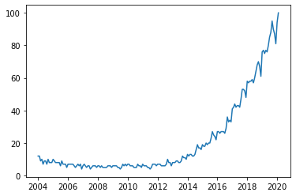

```python
import matplotlib.pyplot as plt
plt.plot(df['date'], df['data science'], label='data science')
```

A paramétercímke a jelmagyarázatot jelzi. Ez nem jelenti azt, hogy meg is jelenik, ehez más parancsot kell használnunk, amelyet később elmagyarázok.

Ugyanazon gráfban több változó grafikonját is elkészíthetjük, és így összehasonlíthatjuk őket.

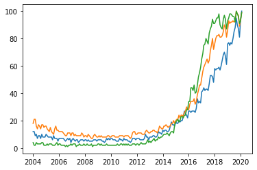

```python
plt.plot(df['date'], df['data science'], label='data science')
plt.plot(df['date'], df['machine learning'], label='machine learning')
plt.plot(df['date'], df['deep learning'], label='deep learning')
```

OK DE nem világos, hogy az egyes színek melyik változót képviselik. Adjunk hozzá jelmagyarázatot is.

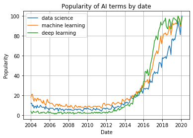

```python
plt.plot(df['date'], df['data science'], label='data science')
plt.plot(df['date'], df['machine learning'], label='machine learning')
plt.plot(df['date'], df['deep learning'], label='deep learning')
plt.xlabel('Date')
plt.ylabel('Popularity')
plt.title('Popularity of AI terms by date')
plt.grid(True)
plt.legend()
```

### többábra egyszerre

Több ábrát is készíthetünk egy ábrán. Ez nagyon jól hasznos a diagramok összehasonlításához vagy a többféle diagramból származó adatok egyszerű megosztásához egyetlen képpel. pl hisztogram és adatsor... v több adatsor összehasonlítására...

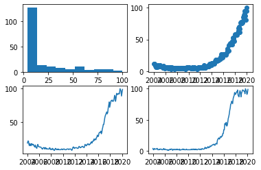

```python
fig, axes = plt.subplots(2,2)
axes[0, 0].hist(df['data science'])
axes[0, 1].scatter(df['date'], df['data science'])
axes[1, 0].plot(df['date'], df['machine learning'])
axes[1, 1].plot(df['date'], df['deep learning'])
```

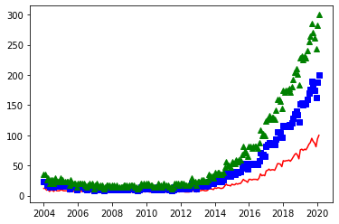

```python
plt.plot(df['date'], df['data science'], 'r-')
plt.plot(df['date'], df['data science']*2, 'bs')
plt.plot(df['date'], df['data science']*3, 'g^')
```

### x-y scatter plot

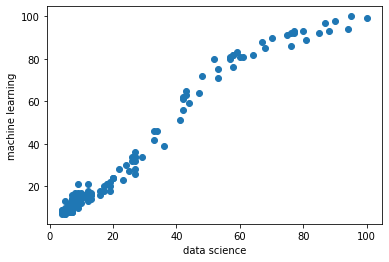

```python
plt.scatter(df['data science'], df['machine learning'])
plt.xlabel('data science')
plt.ylabel('machine learning')
```

### Barchart

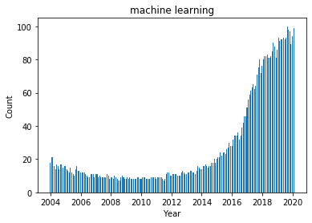

```python
plt.bar(df['date'], df['machine learning'], width=20)
plt.xlabel('Year')
plt.ylabel('Count')
plt.title('machine learning')
```

### hisztogram

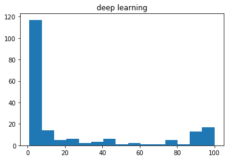

```python
plt.hist(df['deep learning'], bins=15)
plt.title('deep learning')
```

### további szövegek hozzáadása

Hozzáadhatunk egy szöveget a grafikához, a szöveg pozícióját ugyanazokban az egységekben tüntetjük fel, amelyeket a grafikán látunk. A szövegben akár speciális karaktereket is hozzáadhatunk a TeX nyelven.

```python
plt.plot(df['date'], df['data science'], label='data science')
plt.plot(df['date'], df['machine learning'], label='machine learning')
plt.plot(df['date'], df['deep learning'], label='deep learning')
plt.xlabel('Date')
plt.ylabel('Popularity')
plt.title('Popularity of AI terms by date')
plt.grid(True)
plt.text(x='2010-01-01', y=80, s=r'$\lambda=1, r^2=0.8$') #Coordinates use the same units as the graph
plt.annotate('Notice something?', xy=('2014-01-01', 30), xytext=('2006-01-01', 50), arrowprops={'facecolor':'red', 'shrink':0.05})
```

[output not shown]

[output cut: 121 more lines]

[output not shown]

https://matplotlib.org/gallery/index.html

## Seaborn

A Seaborn a Matplotlib alapú könyvtár. Alapvetően az ad nekünk szebb grafikát és funkciókat, hogy összetett típusú grafikákat készítsünk egyetlen kódsorral. Importáljuk a könyvtárat, és inicializáljuk a grafika stílusát az sns.set () paranccsal, e parancs nélkül a grafika továbbra is ugyanolyan stílusú lenne, mint a Matplotlib.

Nem elérhető az online verzióban.

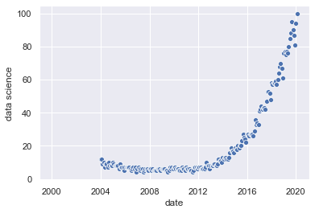

```python
import seaborn as sns
sns.set()
sns.scatterplot(df['date'], df['data science'])
```

### kategoriák felhasználása

Ugyanazon grafikonon több mint két változó adatait is hozzáadhatjuk. Ehhez színeket és méreteket használunk. A kategória oszlop értéke szerint más grafikont is készítünk:

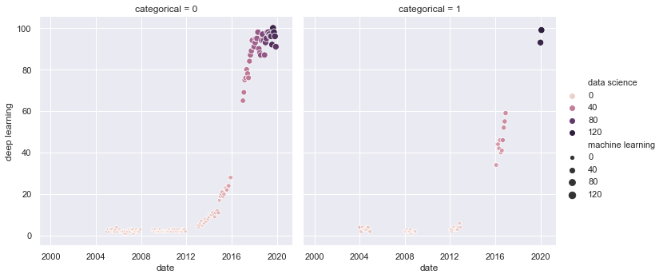

```python
sns.relplot(x='date', y='deep learning', hue='data science', size='machine learning', col='categorical', data=df)
```

### Heatmap/korrel

A Seaborn egyik legnépszerűbb grafikája a hőtérkép. Nagyon gyakori, hogy az adathalmaz változói közötti összes összefüggés megjelenítésére használják Tulajdonképpen egy korrelációs grafikon

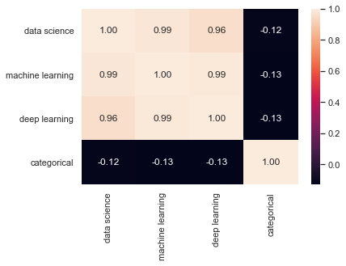

```python
sns.heatmap(df.corr(), annot=True, fmt='.2f')
```

### pairplot

A másik legnépszerűbb a pairplot, amely megmutatja nekünk az összes változó közötti kapcsolatokat. Az adatok dimenziójának növelésével a feldolgozási idő exponenciálisan nő!

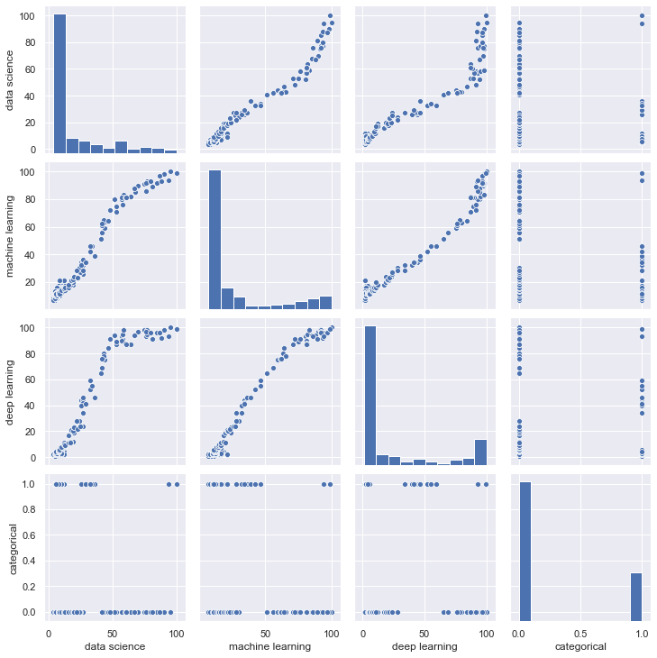

```python
sns.pairplot(df)
```

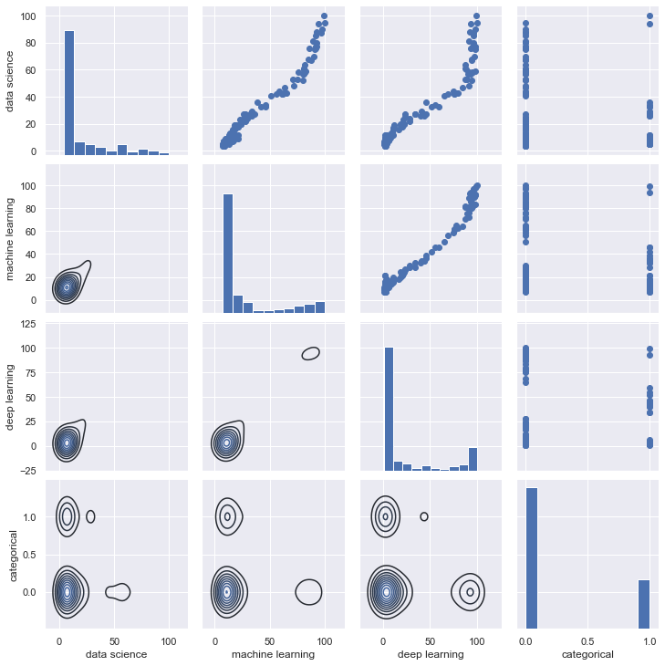

```python
g = sns.PairGrid(df)
g.map_diag(plt.hist)
g.map_upper(plt.scatter)
g.map_lower(sns.kdeplot) # kernel density estimate, diagram egy módszer a megfigyelések eloszlásának megjelenítésére egy adathalmazban, egy hisztogramhoz hasonlóan. A KDE egy valószínűségi sűrűségi görbe segítségével ábrázolja az adatokat egy vagy több dimenzióban.
```

### pairplot és ketg

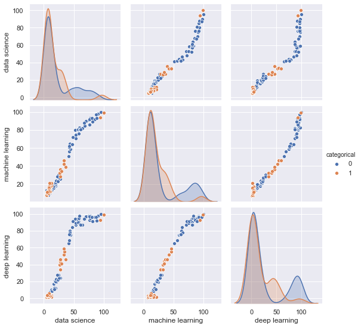

```python
sns.pairplot(df, hue='categorical')
```

### jointplot

lehetővé teszi számunkra, hogy a x-y scatterplot vagy szórásképet a két változó hisztogramjával együtt lássuk

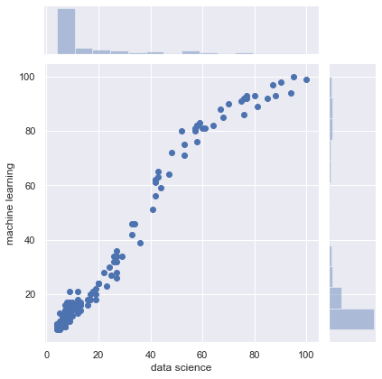

```python
sns.jointplot(x='data science', y='machine learning', data=df)
```

### ViolinPlot

A ViolinPlot informatívabb, mint a sima box plot. Míg a dobozdiagram csak összefoglaló statisztikákat mutat, például átlag/medián és interkvartilis tartományokat, a hegedűdiagram az adatok teljes eloszlását mutatja. A különbség különösen akkor hasznos, ha az adatelosztás multimodális (több mint egy csúcs). Ebben az esetben egy hegedűdiagram különböző csúcsok jelenlétét, helyzetét és relatív amplitúdóját mutatja.

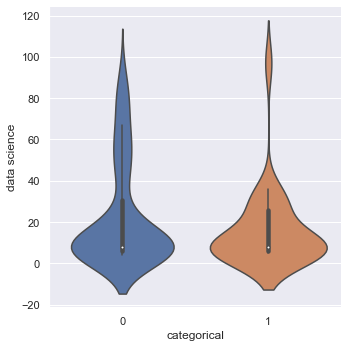

```python
sns.catplot(x='categorical', y='data science', kind='violin', data=df)
```

Több képet is létrehozhatunk egy képen, mint a Matplotlib esetében

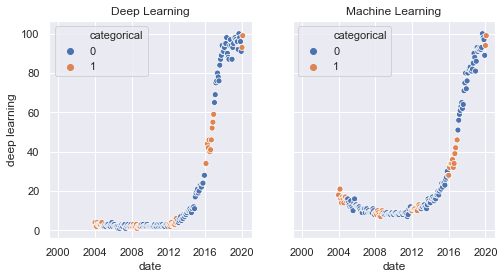

```python
fig, axes = plt.subplots(1, 2, sharey=True, figsize=(8, 4))
sns.scatterplot(x="date", y="deep learning", hue="categorical", data=df, ax=axes[0])
axes[0].set_title('Deep Learning')
sns.scatterplot(x="date", y="machine learning", hue="categorical", data=df, ax=axes[1])
axes[1].set_title('Machine Learning')
```

https://seaborn.pydata.org/examples/index.html

## Bokeh

A Bokeh egy könyvtár, amely lehetővé teszi interaktív grafikák létrehozását. Exportálhatjuk őket egy HTML dokumentumba, amelyet megoszthatunk bárkivel, akinek van webböngészője.

Ez egy nagyon hasznos könyvtár, fontos a grafikában való keresés, vagy szeretnénk nagyítani és mozogni a grafikán. Vagy amikor meg akarjuk osztani ezeket.

Importáljuk a könyvtárat, és meghatározzuk azt a fájlt, amelybe menteni szeretnénk a grafikont

https://tanospeter.github.io/data_science_popularity.html

```python
from bokeh.plotting import figure, output_file, save
output_file('data_science_popularity.html')
```

```python
p = figure(title='data science', x_axis_label='date', y_axis_label='data science')
p.line(df['date'], df['data science'], legend_label='popularity', line_width=2)
save(p)
```

```
'C:\\Users\\Peter\\data_science_popularity.html'
```

### Adding multiple graphics to a single file

nem megy a gridplot https://tanospeter.github.io/multiple_graphs.html

```python
from bokeh.layouts import gridplot
output_file('multiple_graphs.html')
s1 = figure(width=250, plot_height=250, title='data science')
s1.circle(df['date'], df['data science'], size=10, color='navy', alpha=0.5)
s2 = figure(width=250, height=250, x_range=s1.x_range, y_range=s1.y_range, title='machine learning') #share both axis range
s2.triangle(df['date'], df['machine learning'], size=10, color='red', alpha=0.5)
s3 = figure(width=250, height=250, x_range=s1.x_range, title='deep learning') #share only one axis range
s3.square(df['date'], df['deep learning'], size=5, color='green', alpha=0.5)
p = gridplot([[s1, s2, s3]])
save(p)
```

```
'C:\\Users\\Peter\\multiple_graphs.html'
```

https://docs.bokeh.org/en/latest/docs/gallery.html

## Altair

Véleményem szerint az Altair nem hoz semmi újat abba, amit a többi könyvtárral már megbeszéltünk, és ezért nem fogok erről részletesen beszélni. Azért szeretném megemlíteni ezt a könyvtárat, mert talán a saját galériájukban találunk néhány konkrét grafikát, amelyek segíthetnek nekünk. https://altair-viz.github.io/gallery/index.html

## Fólium

A Folium egy könyvtár, amely lehetővé teszi, hogy térképeket, jelölőket rajzoljunk, és rajtuk is rajzolhassuk adatainkat. A Folium lehetővé teszi a szolgáltató kiválasztását, ez határozza meg a térkép stílusát és minőségét. Ebben a cikkben az egyszerűség kedvéért csak az OpenStreetMap -ot tekintjük térképszolgáltatóként.

A térképekkel való munka meglehetősen bonyolult. Itt csak az alapokat nézzük meg, és rajzolunk néhány térképet a rendelkezésünkre álló adatokkal. Kezdjük az alapokkal, rajzolunk egy egyszerű térképet, amin nincs semmi.

https://tanospeter.github.io/map1

```python
import folium
m1 = folium.Map(location=[41.38, 2.17], tiles='openstreetmap', zoom_start=18)
m1.save('map1.html')
```

```python
from geopandas.tools import geocode
df2 = pd.read_csv('mapa.csv')
df2.dropna(axis=0, inplace=True)
df2['geometry'] = geocode(df2['País'], provider='nominatim')['geometry'] #It may take a while because it downloads a lot of data.
df2['Latitude'] = df2['geometry'].apply(lambda l: l.y)
df2['Longitude'] = df2['geometry'].apply(lambda l: l.x)
```

[output not shown]

https://towardsdatascience.com/complete-guide-to-data-visualization-with-python-2dd74df12b5e